# March 20

## principal components

- Find combinations of variables that distinguish the *individuals*.
- See whether a small number of such components explains most of the variability in the data
- if 2 components good, can plot them

### Two test scores for 8 people

```r
my_url="http://www.utsc.utoronto.ca/~butler/d29/test12.txt"
test12=read_table2(my_url)
```

[output not shown]

[output cut: 149 more lines]

[output not shown]

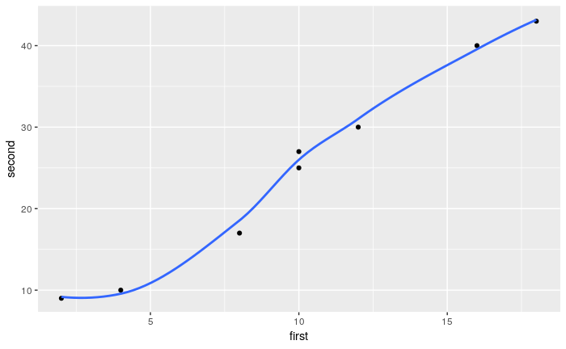

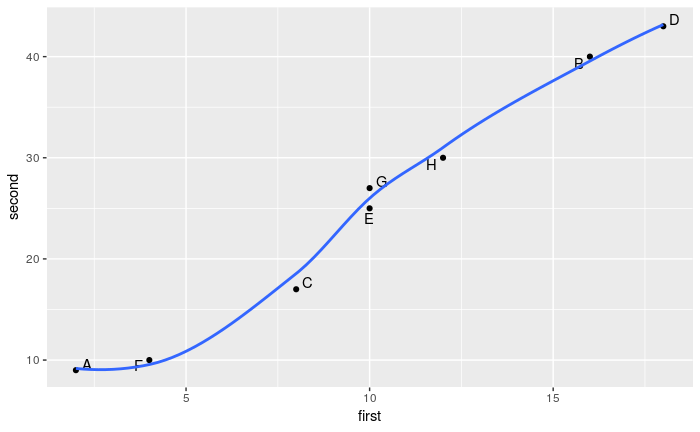

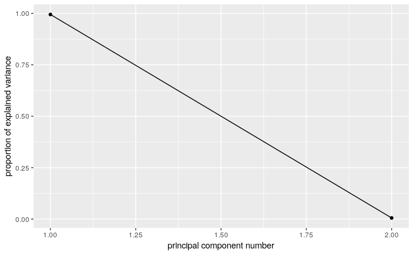

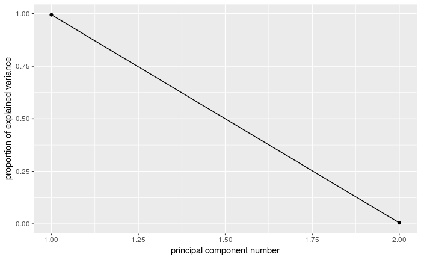

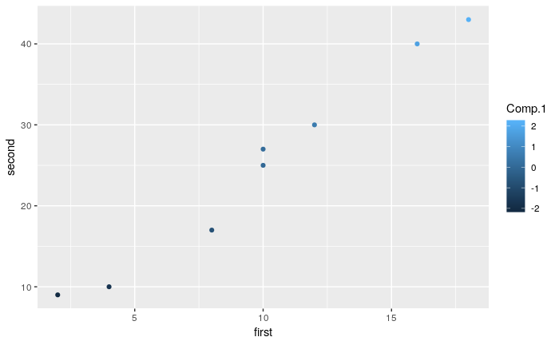

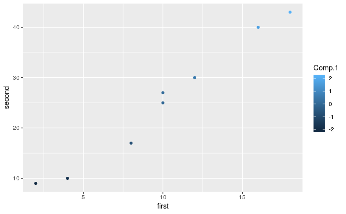

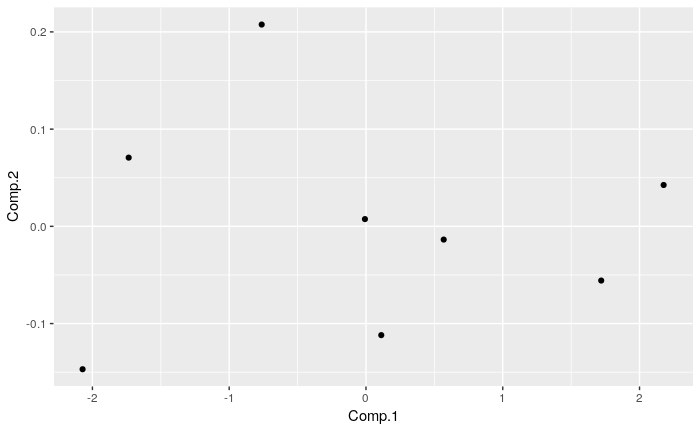

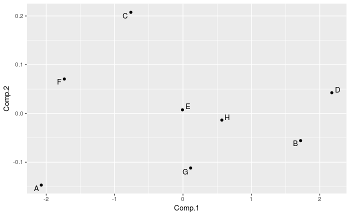

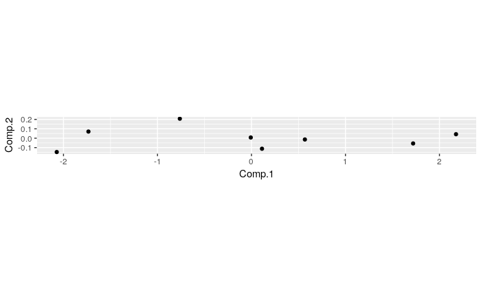

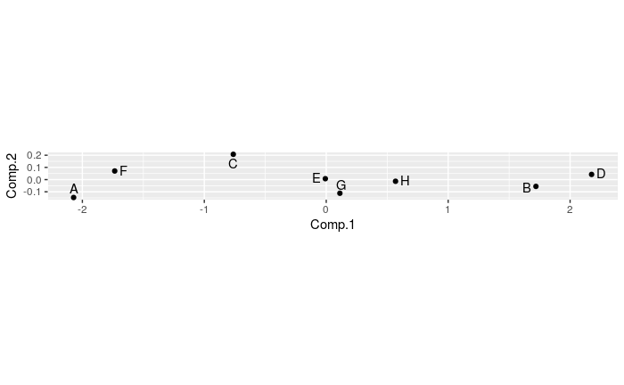

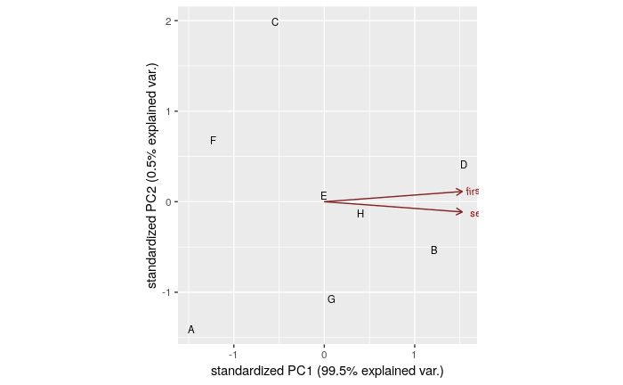

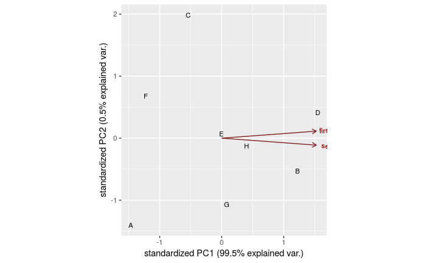

### Track running data

```r
my_url="http://www.utsc.utoronto.ca/~butler/d29/men_track_field.txt"
track=read_table(my_url)
```

[output not shown]

[output cut: 316 more lines]

[output not shown]

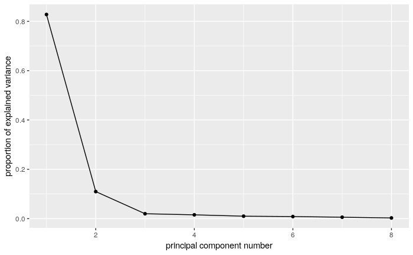

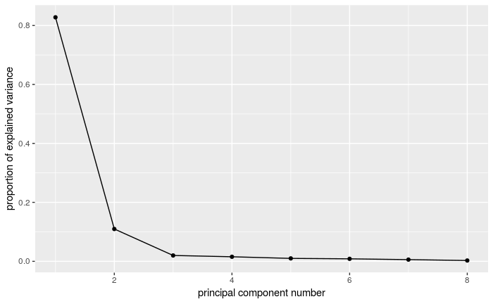

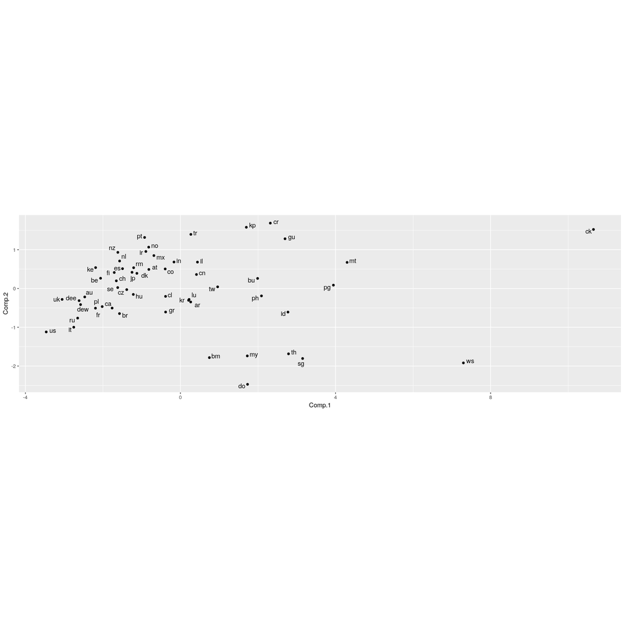

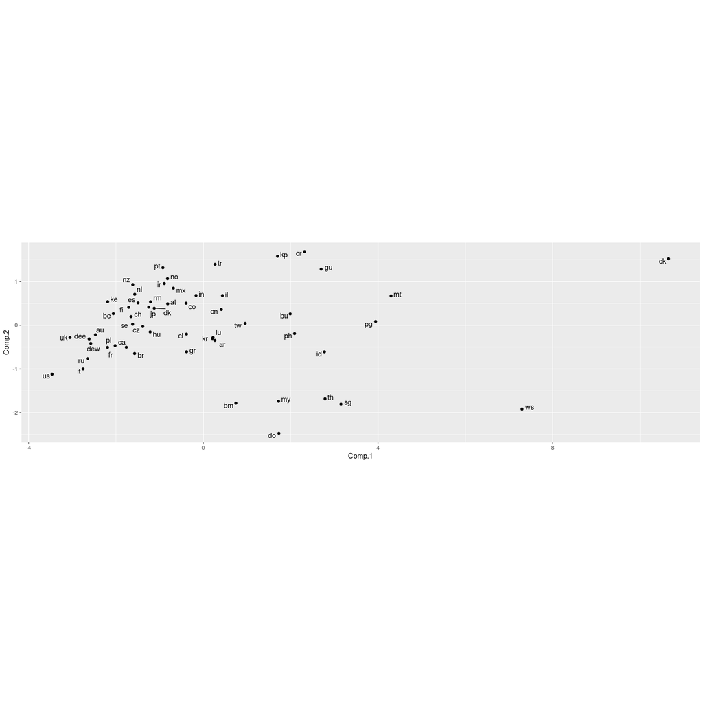

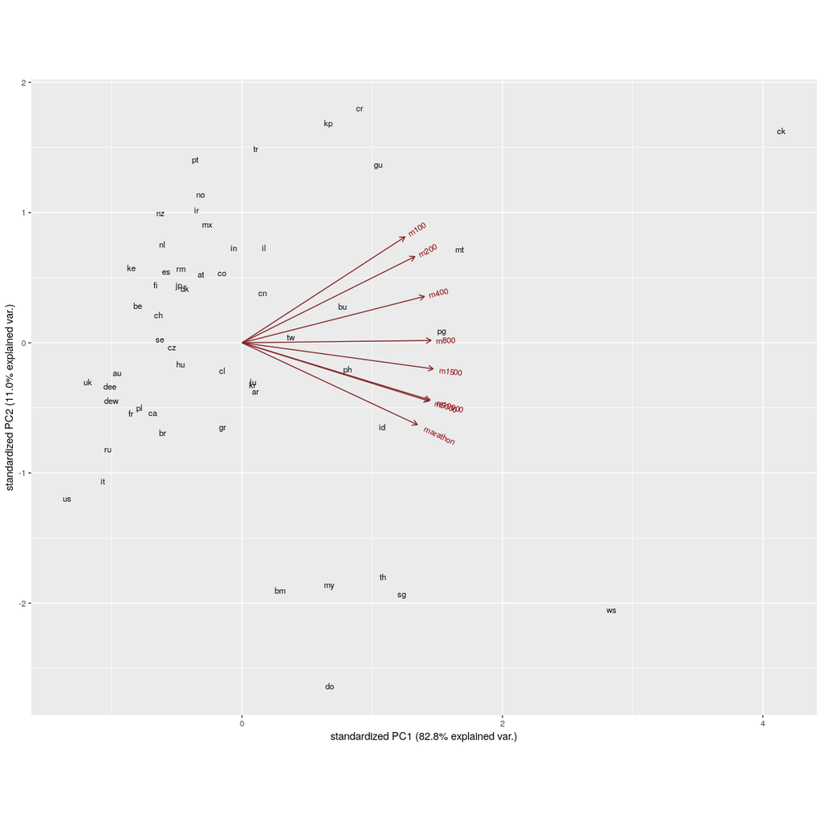

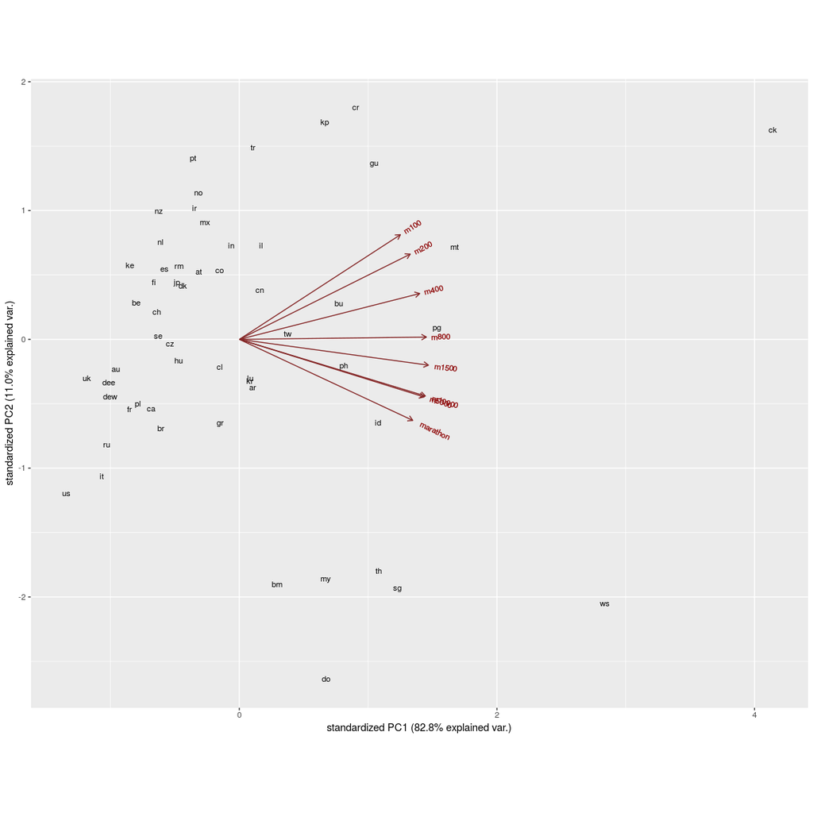

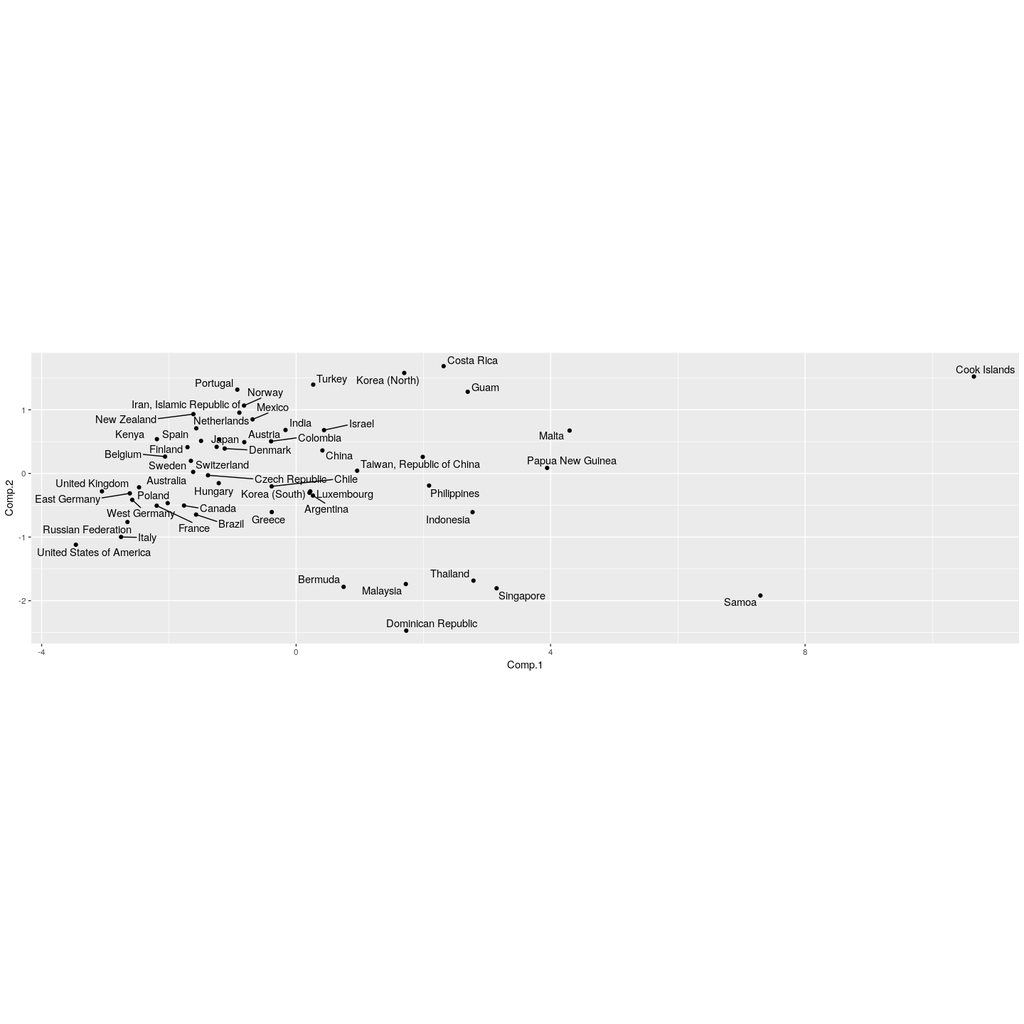

### principal components from correlation matrix

store in file and read in:

```r
my_url="http://www.utsc.utoronto.ca/~butler/d29/cov.txt"
mat=read_table(my_url,col_names=F)
mat
```

[output not shown]

correlations between three variables X1-X3.

```r
mat %>% as.matrix() %>%
princomp(covmat=.) -> mat.pc
summary(mat.pc)
```

[output not shown]

```r
ggscreeplot(mat.pc)
```

[output not shown]

Compare original correlation matrix:

```r
mat
```

[output not shown]

with loadings

```r
mat.pc$loadings
```

[output not shown]

component 1 is large when X1 and X2 are large, X3 small. Small for opposite.

Correlation matrix says that one of these is likely to happen, so data are basically one-dimensional.

see slide 579.